# Milestone 1

Paweł Morgen, Zuzanna Mróz, Aleksander Podsiad

17/03/2020

# 1 Krótkie słowo wstępu

W zbiorze danych *german credit data* znajdują się dane na temat kredytobiorców, klasyfikowanych na podstawie różnych cech (wiek, zatrudnienie, typ miejsca zamieszkania itp.) jako *dobrzy* bądź *źli* klienci. Poniżej zaprezentowano wyniki eksploracji powyższych danych.

# 2 Eksploracja jednowymiarowa

## 2.1 Rozkład czasu trwania kredytu

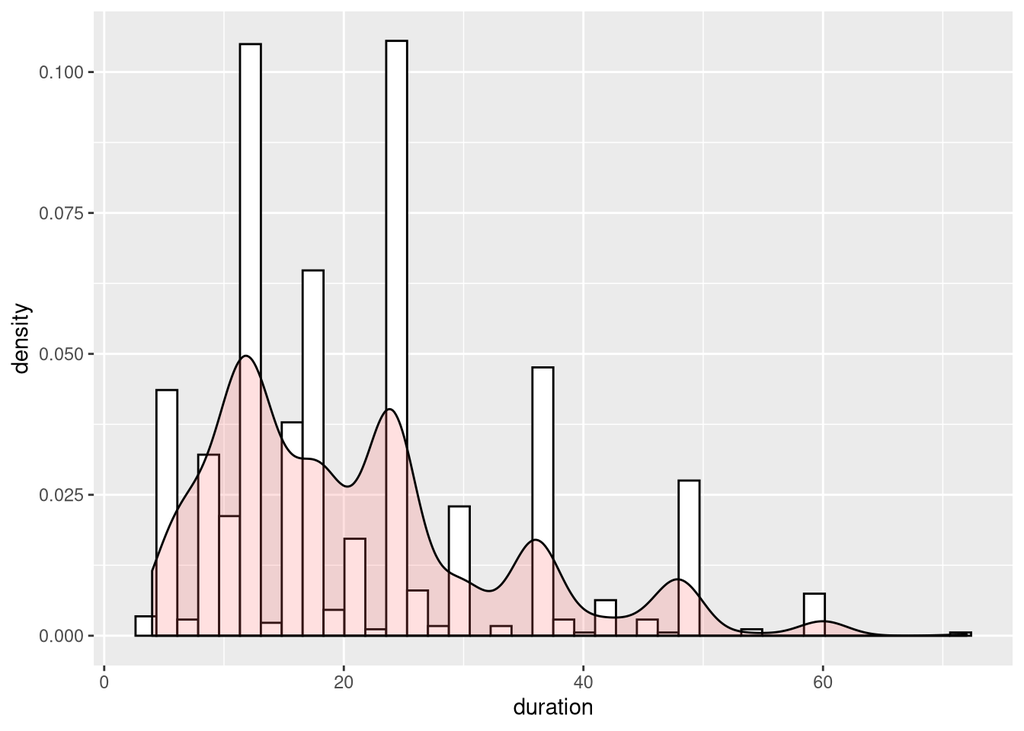

Obserwacje:

- widać wyraźnie, że niektóre czasy trwania kredytu są znacznie popularniejsze.
- najwięcej jest kredytów jedno i dwuletnich.

## 2.2 Rozkład wieku klientów

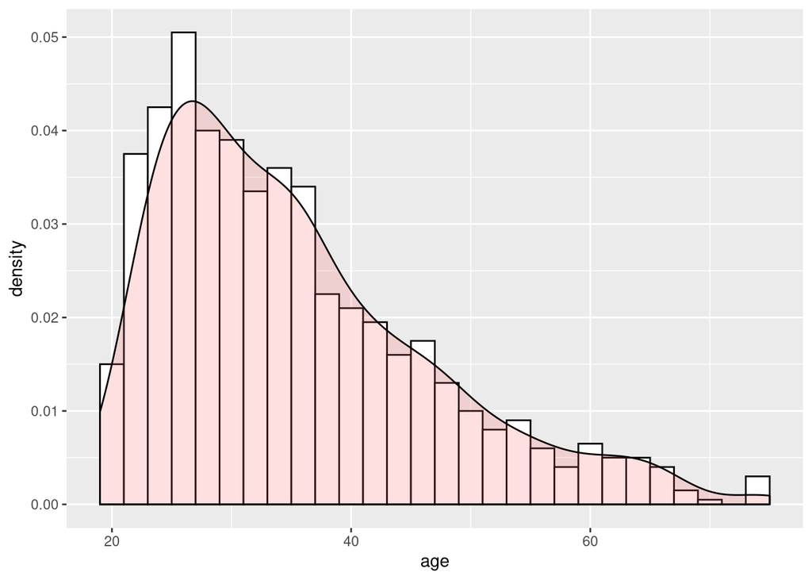

Obserwacje:

- rozkład jest dodatnio skośny ze względu na możliwość brania kredytu dopiero od pewnej granicy wiekowej.
- młodsze osoby częściej biorą kredyty.

## 2.3 Rozkład wysokości kredytu

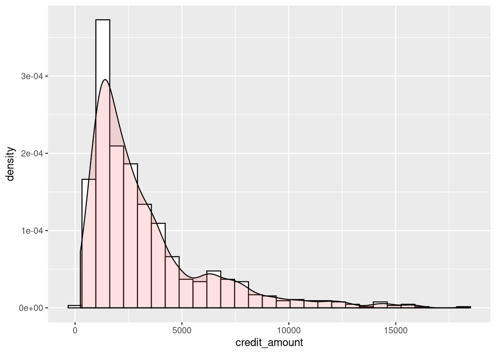

Obserwacje:

- rozkład jest dodatnio skośny z długim ogonem.
- luczie częściej biorą “małe” kredyty.

## 2.4 Wykresy słupkowe zmiennych dyskretnych

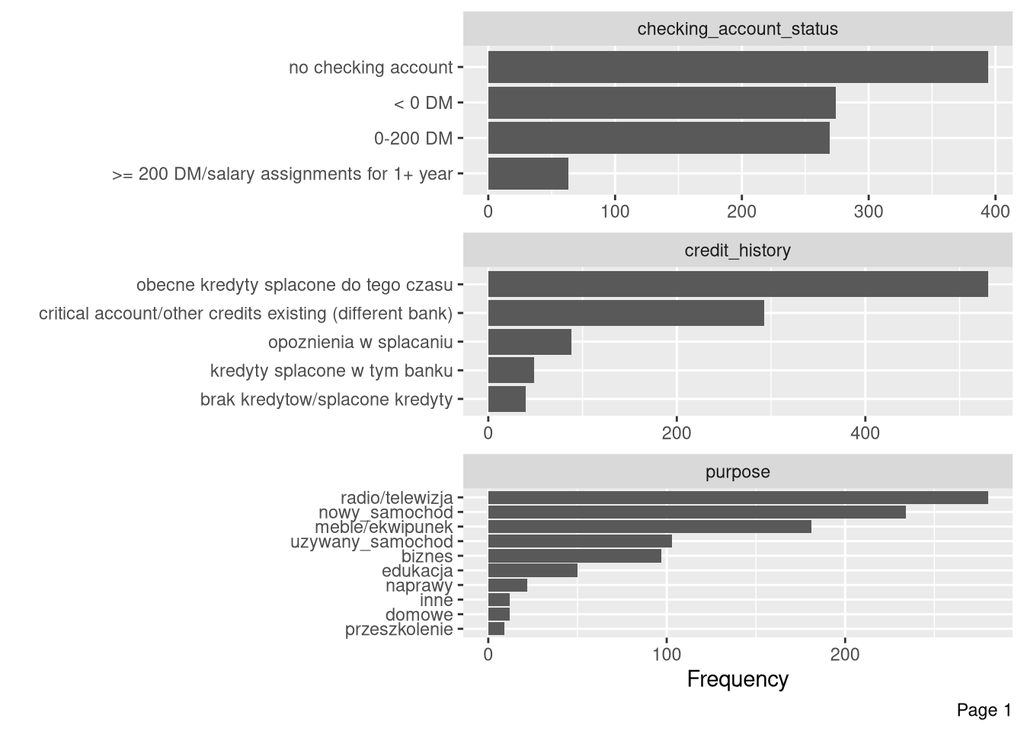

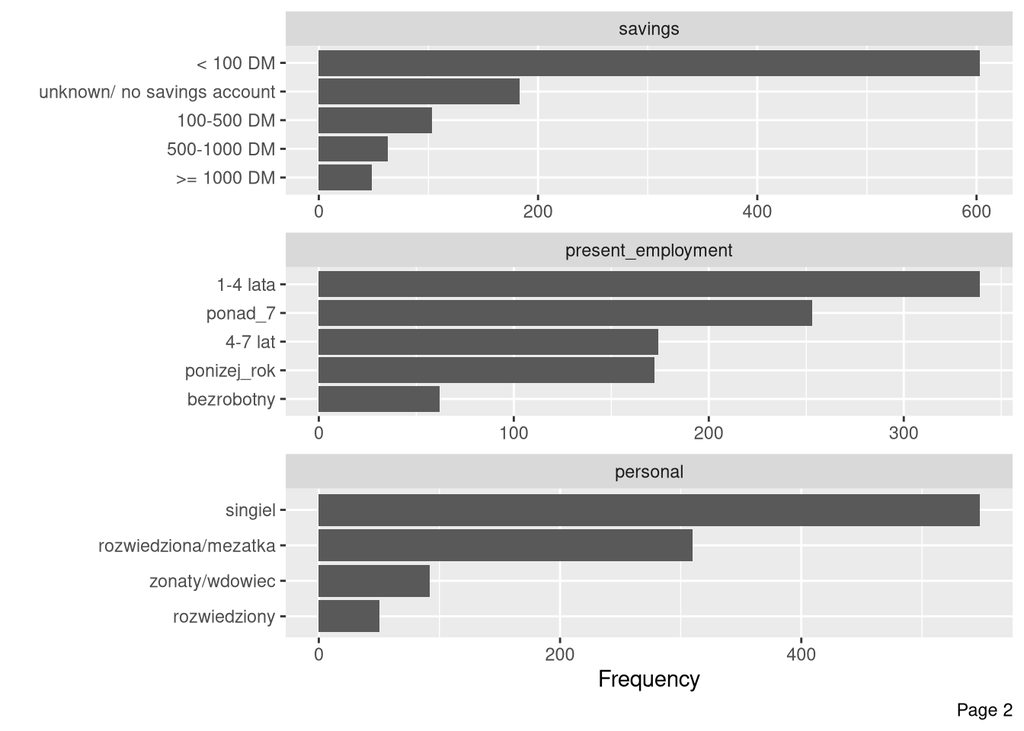

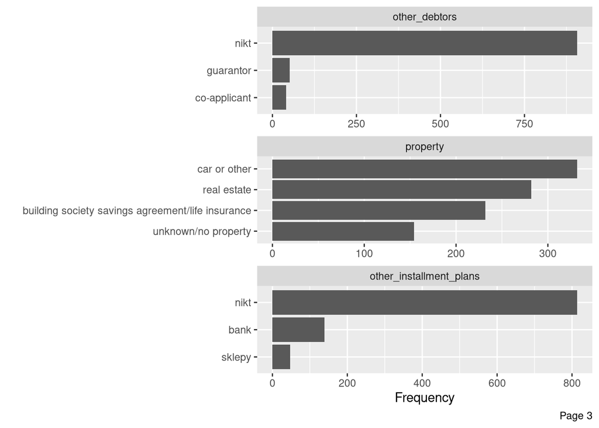

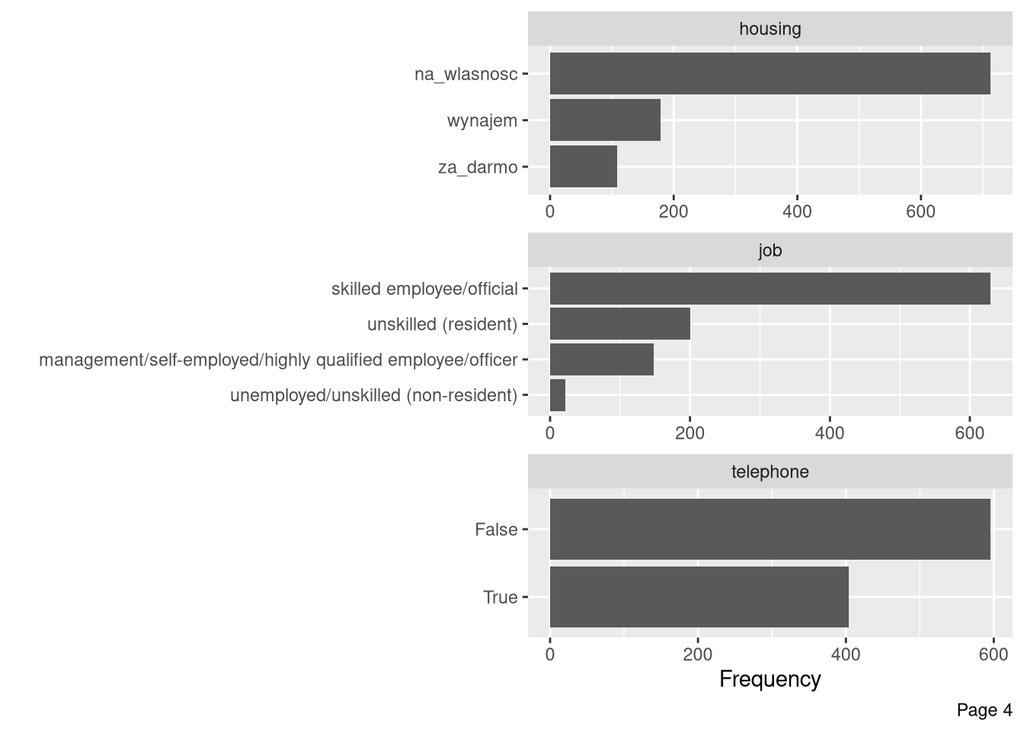

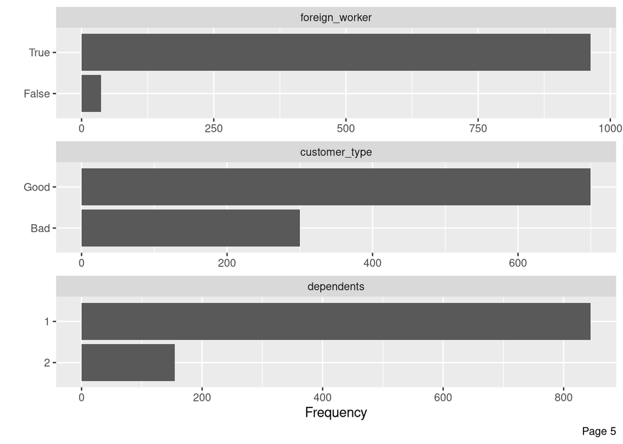

# 3 Eksploracja związków między zmiennymi

## 3.1 Graf korelacji zmiennych

[interactive chart not shown]

Krawędź się rysuje, gdy korelacja między zmiennymi jest nie mniejsza niż 0.2 (co do modułu). Widzimy wzajemne związki wśród zmiennych `property`, `duration`, `credit_amount`, `job`, `telephone` oraz wśród zmiennych `age`, `present_employment` oraz `present_residence`. Przyjrzyjmy się temu bliżej.

## 3.2 Korelacje wszystkich zmiennych

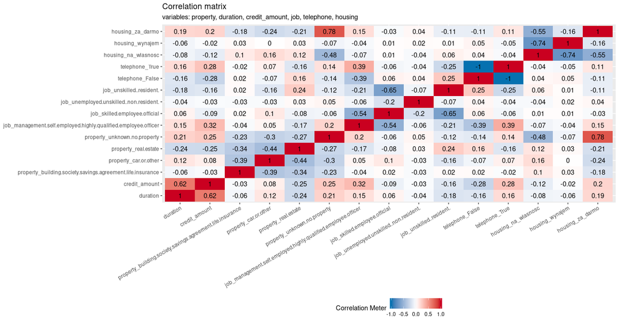

Obserwacje:

- Zmienne `credit_amount` i `duration` są silnie (0.62) skorelowane. Nie dziwi nas to, ponieważ z reguły im kredytów na większe kwoty udziela się na dłuższy czas spłaty.
- Widzimy, że jeśli zmienna `credit_amount` zależy od `job`. Jest to związane ze zdolnością kredytową:

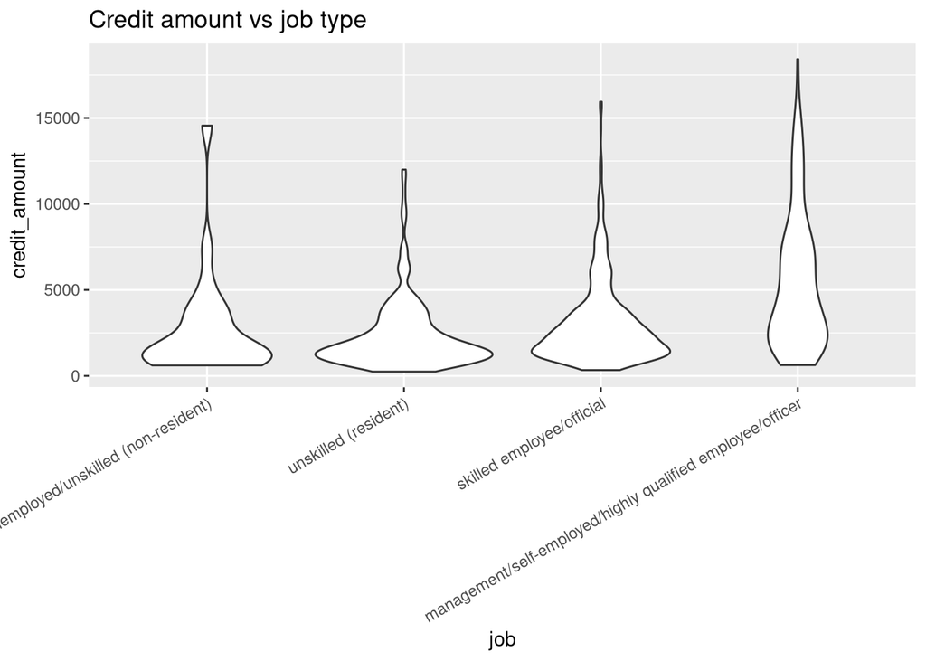

## 3.3 Podsumowanie korelacji

Ogólnie, powyższe związki wynikają w większości z tego, że każdy z nich traktuje o pewnej własności (`telephone`, `housing`, `property`), które są związane ze stanem konta i ze zdolnością kredytową. Im więcej ktoś posiada, tym chętniej bank udziela kredytu na większe kwoty.

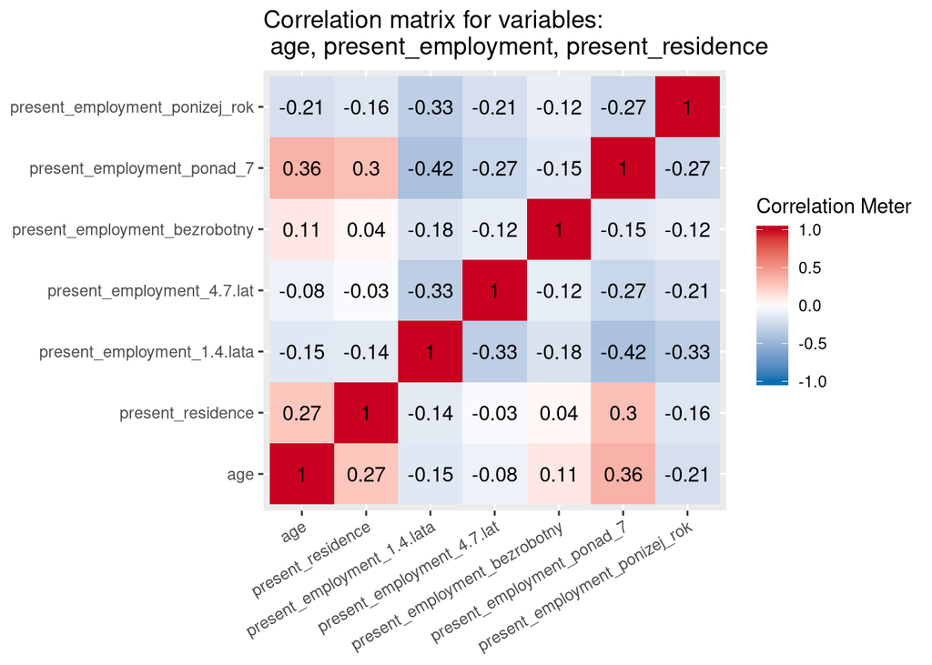

Korelacja pomiędzy zmienną `present_employment` a `age` jest samotłumaczalna - im człowiek starszy, tym więcej miał czasu na pracę. Podobnie z `age` i `present_resident`.

## 3.4 Zależności zmiennych od celu kredytu

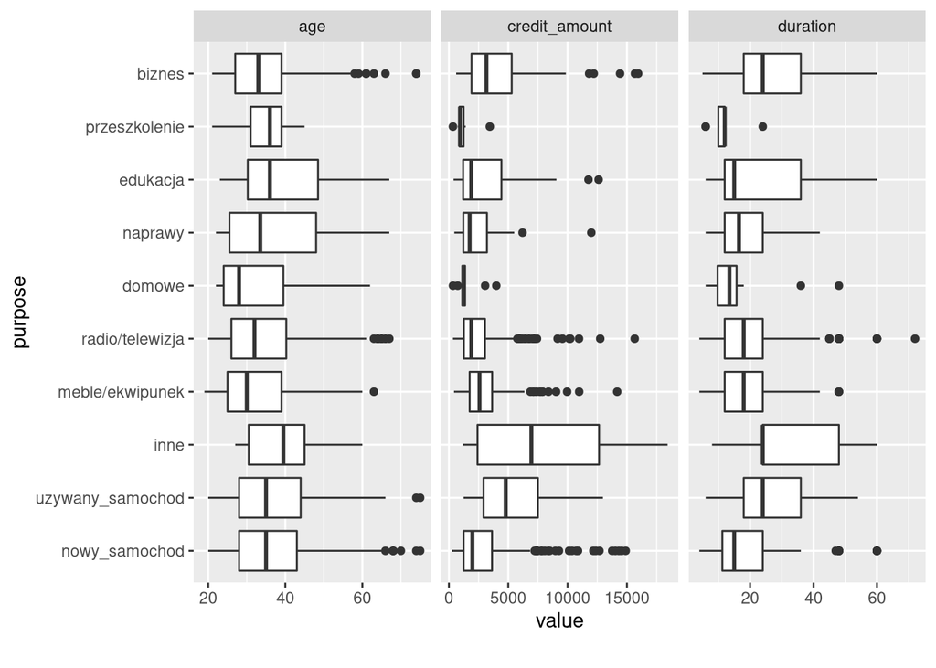

Obserwacje:

- co ciekawe klienci biorą niższe kredyty na nowe samochody niż na używane.
- widać tu wyraźnie korelację wysokości i czasu trwania kredytu.